# Clasificación supervisada de textos

**Note**

**Objetivo:** Introducir modelos supervisados aplicados a texto, implementar Naive Bayes en R y evaluar su desempeño con métricas clásicas de clasificación.

## ¿Qué es la clasificación supervisada de textos?

La clasificación supervisada es una tarea de aprendizaje automático donde el objetivo es **predecir una categoría** (etiqueta) para un nuevo texto, a partir de ejemplos previamente etiquetados.

## Näive Bayes

Representación de texto

Antes de aplicar un modelo, debemos convertir el texto a una representación numérica:

- **Bolsa de palabras (Bag of Words)**
- **TF-IDF (Term Frequency - Inverse Document Frequency)**

En este ejemplo vamos a usar TF-IDF con ayuda del paquete `textrecipes`.

## Dataset

Usaremos un dataset simulado con textos cortos y etiquetas de sentimiento (`pos` o `neg`).

```r
library(tidytext)
library(tidyverse)
library(tidymodels)
library(textrecipes)
library(discrim)
library(naivebayes)
set.seed(123)

datos <- read_csv("comentarios_clasificados.csv") |>
  mutate(clase = as.factor(clase))
```

## Dataset

```r
head(datos)
```

```
# A tibble: 6 × 2
  texto                                                clase
  <chr>                                                <fct>
1 Muy buena atención, volvería sin dudar ¡Gracias!     pos
2 Una pérdida de tiempo total Para nada recomendable.  neg
3 Atención al cliente pésima Fue una sorpresa.         neg
4 Excelente calidad y servicio                         pos
5 El producto llegó roto Realmente excelente.          neg
6 El producto llegó en perfectas condiciones ¡Gracias! pos
```

# Datos de entrenamiento y de prueba

```r
division <- initial_split(datos, prop = 0.5, strata = clase)
datos_train <- training(division)
datos_test <- testing(division)
```

`{recipe}` permite definir una secuencia de pasos para procesar los datos

```r
receta <- recipe(clase ~ texto, data = datos_train) %>%
  step_tokenize(texto, token = "ngrams") %>%
  step_stopwords(texto, language = "es") %>%
  step_tfidf(texto)
```

# Modelo Naive Bayes

```r
modelo_nb <- naive_Bayes() %>%
  set_engine("naivebayes") %>%
  set_mode("classification")
```

## Armo el flujo de trabajo (workflow)

Un workflow en tidymodels es una estructura que combina dos cosas:

Una receta + un modelo: que define qué algoritmo se va a usar

Permite asegurarse de que el preprocesamiento y el modelo se apliquen juntos

```r
flujo <- workflow() %>%
  add_model(modelo_nb) %>%
  add_recipe(receta)
```

## Entrenamiento y predicción final

```r
modelo_final <- fit(flujo, data = datos_train)

predicciones <- predict(modelo_final, new_data = datos_test, type = "prob") %>%
  bind_cols(predict(modelo_final, new_data = datos_test)) %>%
  bind_cols(datos_test)
```

## Evaluación del rendimiento

```r
predicciones %>%
  conf_mat(truth = clase, estimate = .pred_class)
```

```
          Truth
Prediction neg pos
       neg  12  25
       pos  13   0
```

```r
predicciones %>%
  metrics(truth = clase, estimate = .pred_class)
```

```
# A tibble: 2 × 3
  .metric  .estimator .estimate
  <chr>    <chr>          <dbl>
1 accuracy binary          0.24
2 kap      binary         -0.52
```

# Regresión logística ¿Mejorará?

```r
modelo_log <- logistic_reg() %>%
  set_engine("glm") %>%
  set_mode("classification")

flujo <- workflow() %>%
  add_model(modelo_log) %>%
  add_recipe(receta)
```

## Aplico el modelo

```r
modelo_final <- fit(flujo, data = datos_train)

predicciones <- predict(modelo_final, new_data = datos_test, type = "prob") %>%
  bind_cols(predict(modelo_final, new_data = datos_test)) %>%
  bind_cols(datos_test)

predicciones %>%
  conf_mat(truth = clase, estimate = .pred_class)
```

```
          Truth
Prediction neg pos
       neg  25   3
       pos   0  22
```

```r
predicciones %>%
  metrics(truth = clase, estimate = .pred_class)
```

```
# A tibble: 2 × 3
  .metric  .estimator .estimate
  <chr>    <chr>          <dbl>
1 accuracy binary          0.94
2 kap      binary          0.88
```

## Otros modelos para clasificación de texto

- logistic_reg()
- naive_Bayes()
- vm_linear()
- rand_forest()
- boost_tree() con engine = “xgboost”

# N-grams

## Tokenización

```r
datos_bigrams <- datos %>%
  unnest_tokens(bigram, texto, token = "ngrams", n = 2) %>%
  filter(!is.na(bigram))

datos_bigrams
```

```
# A tibble: 600 × 2
   clase bigram
   <fct> <chr>
 1 pos   muy buena
 2 pos   buena atención
 3 pos   atención volvería
 4 pos   volvería sin
 5 pos   sin dudar
 6 pos   dudar gracias
 7 neg   una pérdida
 8 neg   pérdida de
 9 neg   de tiempo
10 neg   tiempo total
# ℹ 590 more rows
```

## Bigramas más comunes

```r
datos_bigrams %>%
  count(bigram, sort = TRUE)
```

```
# A tibble: 156 × 2
   bigram                  n
   <chr>               <int>
 1 lo que                 15
 2 nada recomendable      13
 3 para nada              13
 4 no lo                  11
 5 definitivamente sí      9
 6 el producto             9
 7 producto llegó          9
 8 realmente excelente     9
 9 totalmente conforme     9
10 calidad y               8
# ℹ 146 more rows
```

# Eliminamos stopwords

```r
library(tidyr)

bigrams_separated <- datos_bigrams %>%
  separate(bigram, c("word1", "word2"), sep = " ")

bigrams_filtered <- bigrams_separated %>%
  filter(!word1 %in% stop_words$word) %>%
  filter(!word2 %in% stop_words$word)

bigram_counts <- bigrams_filtered %>%
  count(word1, word2, sort = TRUE)

bigram_counts
```

```
# A tibble: 132 × 3
   word1           word2            n
   <chr>           <chr>        <int>
 1 nada            recomendable    13
 2 para            nada            13
 3 definitivamente sí               9
 4 el              producto         9
 5 producto        llegó            9
 6 realmente       excelente        9
 7 totalmente      conforme         9
 8 excelente       calidad          8
 9 fue             una              8
10 jamás           volveré          8
# ℹ 122 more rows
```

## También puede interesar que sean 3 palabras consecutivas

```r
datos %>%
  unnest_tokens(trigram, texto, token = "ngrams", n = 3) %>%
  filter(!is.na(trigram)) %>%
  separate(trigram, c("word1", "word2", "word3"), sep = " ") %>%
  filter(!word1 %in% stop_words$word,
         !word2 %in% stop_words$word,
         !word3 %in% stop_words$word) %>%
  count(word1, word2, word3, sort = TRUE)
```

```
# A tibble: 137 × 4
   word1     word2     word3            n
   <chr>     <chr>     <chr>        <int>
 1 para      nada      recomendable    13
 2 el        producto  llegó            9
 3 fue       una       sorpresa         8
 4 nunca     llegó     lo               8
 5 caro      para      lo               7
 6 demasiado caro      para             7
 7 encantó   la        película         7
 8 joya      repetiría sin              7
 9 la        disfruté  mucho            7
10 la        película  la               7
# ℹ 127 more rows
```

## Es útil para análisis exploratorio de texto

```r
bigrams_filtered %>%
  filter(word2 == "recomendable") %>%
  count(word1, sort = TRUE)
```

```
# A tibble: 2 × 2
  word1     n
  <chr> <int>
1 nada     13
2 muy       4
```

## ¿Cómo se relacionan las palabras?

```r
library(igraph)
library(ggraph)

bigram_counts %>%
  filter(n > 2) %>%
  graph_from_data_frame() |>
  ggraph(layout = "fr") +
  geom_edge_link() +
  geom_node_point() +
  geom_node_text(aes(label = name), vjust = 1, hjust = 1)
```

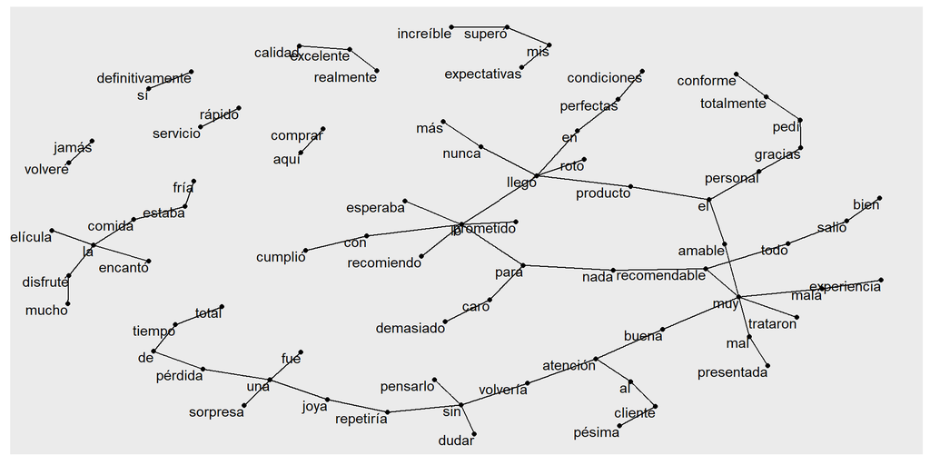

## Más bonito

```r
a <- grid::arrow(type = "closed", length = unit(.15, "inches"))
bigram_counts %>%
  filter(n > 5) %>%
  graph_from_data_frame() |>
  ggraph(layout = "fr") +
  geom_edge_link(aes(edge_alpha = n), show.legend = FALSE,
                 arrow = a, end_cap = circle(.07, 'inches')) +
  geom_node_point(color = "lightblue", size = 5) +
  geom_node_text(aes(label = name), vjust = 1, hjust = 1) +
  theme_void()
```

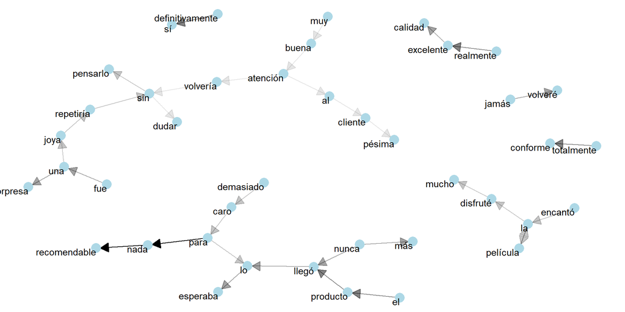

## Correlación

```r
datos_corr <- datos |>
  mutate(tipo_comentario = ifelse(clase == "pos", 1, 2)) %>%
  unnest_tokens(word, texto) %>%
  filter(!word %in% stop_words$word)
```

## Conteo por pares

```r
library(widyr)

word_pairs <- datos_corr %>%
  pairwise_count(word, tipo_comentario, sort = TRUE)

word_pairs %>%
  filter(item1 == "producto")
```

```
# A tibble: 79 × 3
   item1    item2            n
   <chr>    <chr>        <dbl>
 1 producto muy              2
 2 producto atención         2
 3 producto volvería         2
 4 producto gracias          2
 5 producto una              2
 6 producto para             2
 7 producto nada             2
 8 producto recomendable     2
 9 producto fue              2
10 producto sorpresa         2
# ℹ 69 more rows
```

## Correlación por pares - Coeficiente Phi

El [coeficiente phi](https://en.wikipedia.org/wiki/Phi_coefficient) es una medida común de correlación binaria. El coeficiente phi se centra en la probabilidad de que aparezcan las **palabras** X e Y, o **ninguna** , que de que una aparezca sin la otra.

```r
word_cors <- datos_corr %>%
  group_by(word) %>%
  filter(n() >= 5) %>%
  pairwise_cor(word, tipo_comentario, sort = TRUE)

word_cors
```

```
# A tibble: 3,306 × 3
   item1     item2 correlation
   <chr>     <chr>       <dbl>
 1 sin       buena           1
 2 dudar     buena           1
 3 calidad   buena           1
 4 servicio  buena           1
 5 joya      buena           1
 6 repetiría buena           1
 7 pensarlo  buena           1
 8 encantó   buena           1
 9 película  buena           1
10 disfruté  buena           1
# ℹ 3,296 more rows
```

## Observamos

```r
word_cors %>%
  filter(item1 == "atención")
```

```
# A tibble: 57 × 3
   item1    item2        correlation
   <chr>    <chr>              <dbl>
 1 atención muy                  NaN
 2 atención buena                NaN
 3 atención volvería             NaN
 4 atención sin                  NaN
 5 atención dudar                NaN
 6 atención gracias              NaN
 7 atención una                  NaN
 8 atención para                 NaN
 9 atención nada                 NaN
10 atención recomendable         NaN
# ℹ 47 more rows
```

## Palabras mas asociadas

```r
plot <- word_cors %>%
  filter(item1 %in% c("comida", "servicio", "cliente")) %>%
  group_by(item1) %>%
  ungroup() %>%
  drop_na(correlation) |>
  mutate(item2 = reorder(item2, correlation)) %>%
  ggplot(aes(item2, correlation)) +
  geom_bar(stat = "identity") +
  facet_wrap(~ item1, scales = "free") +
  coord_flip()
```

## Palabras mas asociadas

```r
plot
```

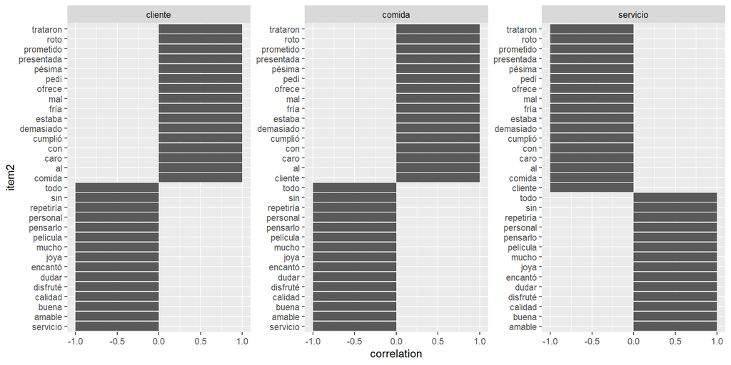

## Graficamos palabras más relacionadas

```r
set.seed(2016)
plot <- word_cors %>%
  drop_na(correlation) |>
  filter(correlation > .35) %>%
  graph_from_data_frame() %>%
  ggraph(layout = "fr") +
  geom_edge_link(aes(edge_alpha = correlation), show.legend = FALSE) +
  geom_node_point(color = "lightblue", size = 5) +
  geom_node_text(aes(label = name), repel = TRUE) +
  theme_void()
```

## Graficamos palabras más relacionadas

```r
plot
```

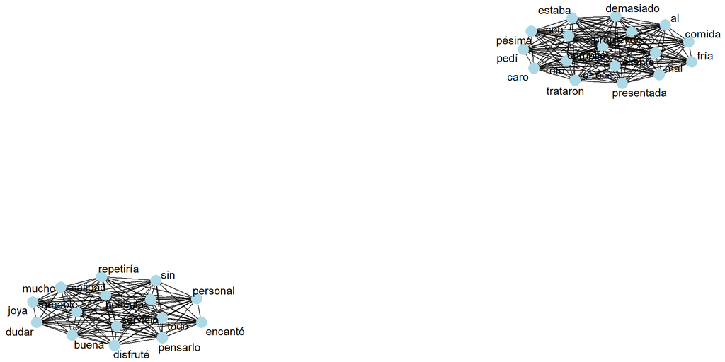